# CURSO CIENCIA DE DATOS - CLASE 6

Franco Galeano

UTDT, 2022

# ANÁLISIS Y VISUALIZACIÓN DE DATOS 3

## To do

Hoy aprenderemos un poco más sobre **visualización de datos**.

Siendo más específicos, hoy veremos:

- ¿Cómo describir una base de datos?: Uso del comando `skimr::skim()`
- Media, mediana, moda, quintiles/deciles, correlación y análisis bivariados.
- Introducción a tablas con kable, kableextra y DT.

Hoy trabajaremos con la base de datos sobre [Distribución del empleo formal en el AMBA](https://datos.produccion.gob.ar/dataset/distribucion-del-empleo-formal-en-el-amba), publicada por el Centro de Estudios para la Producción (CEP-XXI) a partir de datos del SIPA y de AFIP

Aquí pueden ver una captura de una visualización a partir de esos datos. El azul más oscuro refleja la mayor relevancia del empleo industrial en esa zona

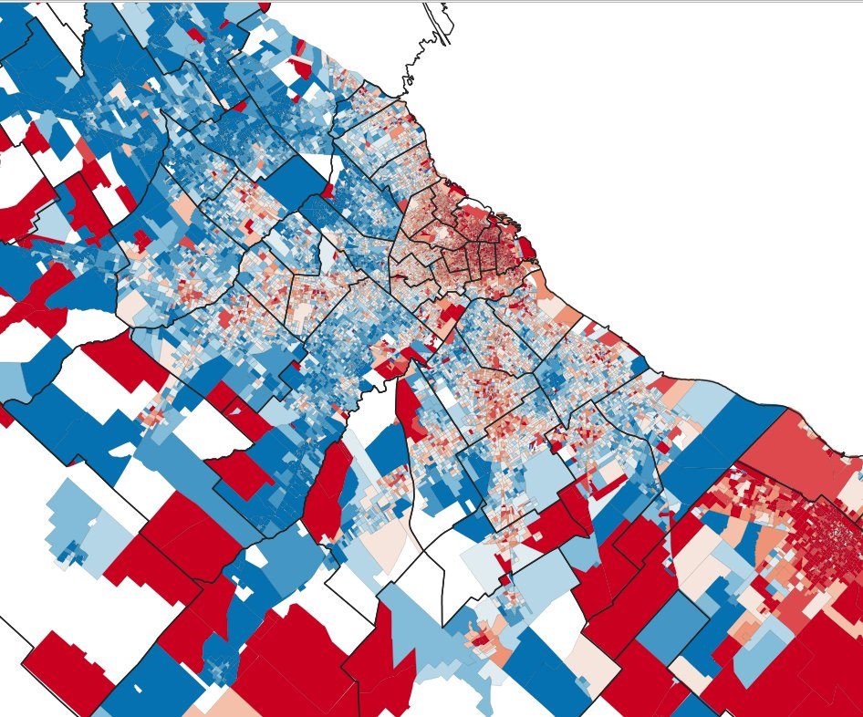

Fuente: @danyscht

```r
#Importar paquetes
library(tidyverse)
library(janitor)
library(skimr) # para descripcion rápida de bases
library(knitr) #para tablas
library(kableExtra) #para tablas
```

```r
# Importamos Datos
jurisdicciones <- read_csv("https://cdn.produccion.gob.ar/cdn-cep/amba-aportantes/jurisdicciones.csv") %>%
  clean_names()
actividades <- read_csv("https://cdn.produccion.gob.ar/cdn-cep/amba-aportantes/actividades.csv") %>%
  clean_names()
empleo_amba <- read_csv("https://cdn.produccion.gob.ar/cdn-cep/amba-aportantes/Empleo-AMBA.csv") %>%
  clean_names()
```

Antes de continuar, les presento una última forma de importar datos que puede serles de utilidad.

Con ustedes [Datapasta](https://milesmcbain.github.io/datapasta/). Si quieren importar tablas en html también pueden consultar [aquí](https://cran.r-project.org/web/packages/htmltab/vignettes/htmltab.html).

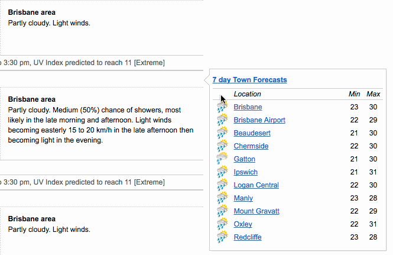

Fuente: Datapasta

## Uso del comando `skimr::skim()`

El paso siguiente, luego de importar nuestros datos es tratar de comprenderlos. Una buena práctica suele ser chequear datos faltantes, rangos de las variables, ver estadísticas descriptivas, etc.

Esta etapa puede tomar algo de tiempo, aunque existen algunos “atajos”. Uno de ellos es el paquete `skimr`. Pueden revisar la [documentación](https://cran.r-project.org/web/packages/skimr/vignettes/skimr.html) luego.

```r
#Lo primero que podemos hacer es llamar a skim() y ver que sucede
skim(empleo_amba)
```

Data summary

| Name | empleo_amba |
| --- | --- |
| Number of rows | 508989 |
| Number of columns | 16 |
| _______________________ |  |
| Column type frequency: |  |
| character | 4 |
| numeric | 12 |
| ________________________ |  |
| Group variables | None |

**Variable type: character**

| skim_variable | n_missing | complete_rate | min | max | empty | n_unique | whitespace |
| --- | --- | --- | --- | --- | --- | --- | --- |
| link | 0 | 1 | 5 | 9 | 0 | 13882 | 0 |
| provincia_id | 0 | 1 | 2 | 2 | 0 | 2 | 0 |
| departamento_id | 0 | 1 | 5 | 5 | 0 | 51 | 0 |
| letra | 68 | 1 | 1 | 1 | 0 | 21 | 0 |

**Variable type: numeric**

| skim_variable | n_missing | complete_rate | mean | sd | p0 | p25 | p50 | p75 | p100 | hist |
| --- | --- | --- | --- | --- | --- | --- | --- | --- | --- | --- |
| clae2 | 68 | 1.00 | 52.10 | 26.03 | 1 | 28.00 | 52.00 | 74.0 | 99 | ▅▆▇▇▇ |
| cantidad_trabajadores | 0 | 1.00 | 4.44 | 7.79 | 1 | 1.00 | 2.00 | 4.0 | 254 | ▇▁▁▁▁ |
| cantidad_trabajadores_hombres | 87988 | 0.83 | 3.03 | 3.99 | 1 | 1.00 | 2.00 | 3.0 | 186 | ▇▁▁▁▁ |
| cantidad_trabajadores_mujeres | 235036 | 0.54 | 3.58 | 5.92 | 1 | 1.00 | 1.00 | 3.0 | 134 | ▇▁▁▁▁ |
| remuneracion_media | 0 | 1.00 | 133480.99 | 357197.20 | 0 | 68911.00 | 99290.42 | 149335.8 | 102996268 | ▇▁▁▁▁ |
| remuneracion_media_hombres | 87988 | 0.83 | 143175.01 | 474918.51 | 0 | 70400.95 | 102637.45 | 157847.5 | 140537742 | ▇▁▁▁▁ |
| remuneracion_media_mujeres | 235036 | 0.54 | 117649.18 | 170400.46 | 0 | 62453.92 | 91435.07 | 135622.9 | 27766783 | ▇▁▁▁▁ |
| remuneracion_mediana | 0 | 1.00 | 125488.75 | 344566.18 | 0 | 66695.44 | 93792.98 | 140609.9 | 102996268 | ▇▁▁▁▁ |
| remuneracion_mediana_hombres | 87988 | 0.83 | 136306.13 | 466201.30 | 0 | 68741.88 | 98433.26 | 150189.7 | 140537742 | ▇▁▁▁▁ |
| remuneracion_mediana_mujeres | 235036 | 0.54 | 112979.24 | 165940.86 | 0 | 60375.11 | 87867.76 | 129774.3 | 27766783 | ▇▁▁▁▁ |
| poblacion_radio | 0 | 1.00 | 1029.98 | 419.09 | 53 | 754.00 | 946.00 | 1225.0 | 5895 | ▇▂▁▁▁ |
| viviendas_radio | 0 | 1.00 | 357.03 | 123.43 | 12 | 278.00 | 341.00 | 415.0 | 1405 | ▃▇▁▁▁ |

Algo que también permite hacer `skimr` es realizar este mismo trabajo de resumen de la información, pero con variables agrupadas. Veamos los mismos datos pero agrupando por jurisdicción

```r
empleo_amba %>%
  group_by(provincia_id) %>%
  skim()
```

Data summary

| Name | Piped data |
| --- | --- |
| Number of rows | 508989 |
| Number of columns | 16 |
| _______________________ |  |
| Column type frequency: |  |
| character | 3 |
| numeric | 12 |
| ________________________ |  |
| Group variables | provincia_id |

**Variable type: character**

| skim_variable | provincia_id | n_missing | complete_rate | min | max | empty | n_unique | whitespace |
| --- | --- | --- | --- | --- | --- | --- | --- | --- |
| link | 02 | 0 | 1 | 5 | 8 | 0 | 3367 | 0 |
| link | 06 | 0 | 1 | 9 | 9 | 0 | 10515 | 0 |
| departamento_id | 02 | 0 | 1 | 5 | 5 | 0 | 15 | 0 |
| departamento_id | 06 | 0 | 1 | 5 | 5 | 0 | 36 | 0 |
| letra | 02 | 35 | 1 | 1 | 1 | 0 | 21 | 0 |
| letra | 06 | 33 | 1 | 1 | 1 | 0 | 21 | 0 |

**Variable type: numeric**

| skim_variable | provincia_id | n_missing | complete_rate | mean | sd | p0 | p25 | p50 | p75 | p100 | hist |
| --- | --- | --- | --- | --- | --- | --- | --- | --- | --- | --- | --- |
| clae2 | 02 | 35 | 1.00 | 53.69 | 25.74 | 1 | 31.00 | 56.00 | 73.0 | 99 | ▅▅▇▇▆ |
| clae2 | 06 | 33 | 1.00 | 51.40 | 26.13 | 1 | 27.00 | 49.00 | 77.0 | 99 | ▅▆▇▆▇ |
| cantidad_trabajadores | 02 | 0 | 1.00 | 5.62 | 10.32 | 1 | 1.00 | 2.00 | 5.0 | 241 | ▇▁▁▁▁ |
| cantidad_trabajadores | 06 | 0 | 1.00 | 3.91 | 6.29 | 1 | 1.00 | 2.00 | 4.0 | 254 | ▇▁▁▁▁ |
| cantidad_trabajadores_hombres | 02 | 28643 | 0.82 | 3.62 | 5.11 | 1 | 1.00 | 2.00 | 4.0 | 186 | ▇▁▁▁▁ |
| cantidad_trabajadores_hombres | 06 | 59345 | 0.83 | 2.78 | 3.35 | 1 | 1.00 | 2.00 | 3.0 | 120 | ▇▁▁▁▁ |
| cantidad_trabajadores_mujeres | 02 | 56065 | 0.64 | 4.14 | 7.11 | 1 | 1.00 | 2.00 | 4.0 | 113 | ▇▁▁▁▁ |
| cantidad_trabajadores_mujeres | 06 | 178971 | 0.49 | 3.25 | 5.07 | 1 | 1.00 | 1.00 | 3.0 | 134 | ▇▁▁▁▁ |
| remuneracion_media | 02 | 0 | 1.00 | 166286.05 | 547786.95 | 0 | 73767.75 | 114185.77 | 182794.5 | 102996268 | ▇▁▁▁▁ |
| remuneracion_media | 06 | 0 | 1.00 | 118905.27 | 224197.23 | 0 | 66989.92 | 94799.85 | 136438.6 | 90384441 | ▇▁▁▁▁ |
| remuneracion_media_hombres | 02 | 28643 | 0.82 | 183085.12 | 772937.37 | 0 | 74290.50 | 118410.09 | 196433.5 | 140537742 | ▇▁▁▁▁ |
| remuneracion_media_hombres | 06 | 59345 | 0.83 | 125752.27 | 249407.45 | 0 | 68970.26 | 98000.00 | 144355.5 | 90384441 | ▇▁▁▁▁ |
| remuneracion_media_mujeres | 02 | 56065 | 0.64 | 139992.92 | 206656.93 | 0 | 68573.96 | 104074.81 | 163691.8 | 17268912 | ▇▁▁▁▁ |
| remuneracion_media_mujeres | 06 | 178971 | 0.49 | 104699.99 | 143724.33 | 0 | 59750.83 | 86455.94 | 121877.7 | 27766783 | ▇▁▁▁▁ |
| remuneracion_mediana | 02 | 0 | 1.00 | 150865.13 | 528558.79 | 0 | 70000.00 | 104265.59 | 164623.6 | 102996268 | ▇▁▁▁▁ |
| remuneracion_mediana | 06 | 0 | 1.00 | 114213.68 | 216644.67 | 0 | 65532.93 | 90420.60 | 131151.7 | 90384441 | ▇▁▁▁▁ |
| remuneracion_mediana_hombres | 02 | 28643 | 0.82 | 169556.42 | 760699.29 | 0 | 71463.54 | 110000.00 | 179120.1 | 140537742 | ▇▁▁▁▁ |
| remuneracion_mediana_hombres | 06 | 59345 | 0.83 | 121790.73 | 242729.74 | 0 | 67776.27 | 94700.87 | 139926.7 | 90384441 | ▇▁▁▁▁ |
| remuneracion_mediana_mujeres | 02 | 56065 | 0.64 | 131900.00 | 199712.05 | 0 | 64828.96 | 98422.64 | 151840.4 | 17268912 | ▇▁▁▁▁ |
| remuneracion_mediana_mujeres | 06 | 178971 | 0.49 | 102013.82 | 141606.21 | 0 | 58315.26 | 83873.27 | 118529.4 | 27766783 | ▇▁▁▁▁ |
| poblacion_radio | 02 | 0 | 1.00 | 831.54 | 266.74 | 103 | 678.00 | 805.00 | 940.0 | 3945 | ▇▅▁▁▁ |
| poblacion_radio | 06 | 0 | 1.00 | 1118.15 | 443.61 | 53 | 824.00 | 1055.00 | 1349.0 | 5895 | ▇▅▁▁▁ |
| viviendas_radio | 02 | 0 | 1.00 | 414.96 | 140.62 | 14 | 322.00 | 388.00 | 474.0 | 1405 | ▂▇▁▁▁ |
| viviendas_radio | 06 | 0 | 1.00 | 331.29 | 105.19 | 12 | 262.00 | 322.00 | 391.0 | 1370 | ▅▇▁▁▁ |

## Media, mediana, moda, quintiles/deciles, correlación y análisis bivariados.

Como vemos en la tabla de arriba, figuran la media (mean), desvío estándar (sd), la mediana (p50), algunos cuartiles (p25, p75), y valores mínimos (p0) y máximos (p100).

En unas breves líneas trataremos de mostrar cómo calcularlos, algunas de las cosas que veremos abajo se inspiran en este [manual](https://bookdown.org/gboccardo/manual-ED-UCH/estadistica-descriptiva-con-rstudio.html).

Recordemos:

- El promedio se `mean()`
- La mediana se calcular con `median()`
- El desvío estándar se calcula con `sd()`
- El valor mínimo `min()`
- El valor máximo `max()`
- Los cuantiles se calculan con la función `quantile()`

Estos comandos mencionados previamente, los hemos ido visitando por el curso. Algo que podríamos querer hacer ahora es avanzar un poco más, y tratar de ver la relación que existe entre dos variables continuas. Esto en estadística se conoce como la **correlación**, e indica tanto la fuerza como la dirección de una relación lineal y proporcional entre dos variables.

Aquí para explicarlo con gráficos:

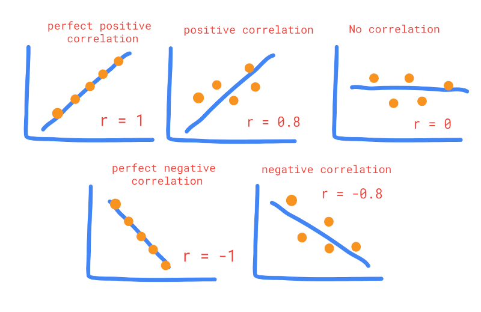

Fuente: https://www.reneshbedre.com/

Recordemos igual, que exista alguna correlación entre nuestras variables no implica correlación. **CORRELACIÓN NO IMPLICA CAUSALIDAD**.

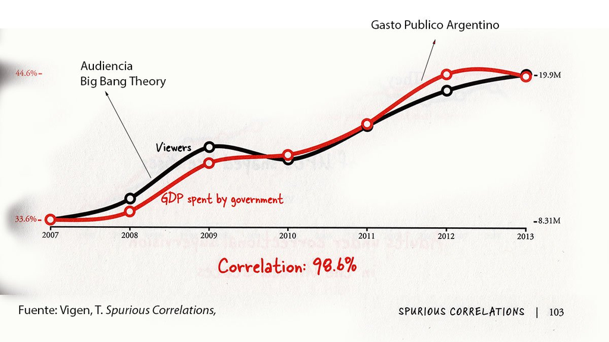

Fuente: @wsosaescudero

Si quieren ver más ejemplos graciosos pueden consultar [acá](https://www.tylervigen.com/spurious-correlations).

Ahora veamos un ejemplo de esto que estamos mencionando

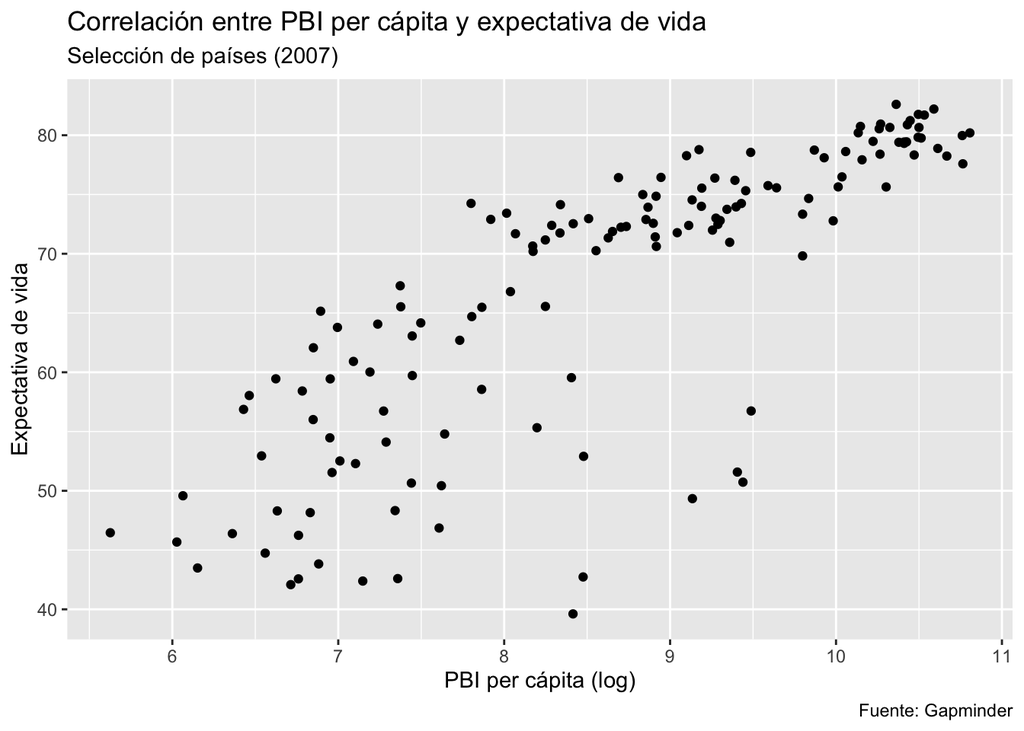

```r
#Importamos datos sobre paises
data_mundial <- read_csv("https://bitsandbricks.github.io/data/gapminder.csv")

#Ploteamos relacion
data_mundial %>%
  filter(anio == 2007) %>%
  ggplot() +
  geom_point(aes(x = log(PBI_PC), y = expVida)) +
  labs(title = "Correlación entre PBI per cápita y expectativa de vida",
       subtitle = "Selección de países (2007)",
       y = "Expectativa de vida",
       x = "PBI per cápita (log)",
       caption = "Fuente: Gapminder")
```

**Ahora podríamos hacer lo mismo, pero agregando una recta de regresión**

Chequeen lo de `method = "lm"`

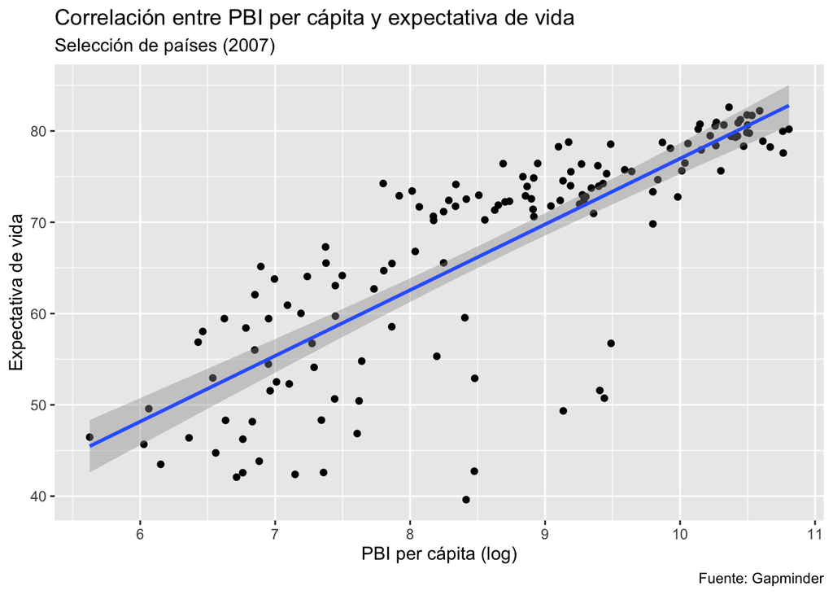

```r
#Ploteamos relacion
data_mundial %>%
  filter(anio == 2007) %>%
  ggplot() +
  geom_point(aes(x = log(PBI_PC), y = expVida)) +
  geom_smooth(mapping = aes(x = log(PBI_PC), y = expVida),
              method = "lm") +
  labs(title = "Correlación entre PBI per cápita y expectativa de vida",
       subtitle = "Selección de países (2007)",
       y = "Expectativa de vida",
       x = "PBI per cápita (log)",
       caption = "Fuente: Gapminder")
```

Si queremos saber el coeficiente de correlación, podríamos hacer lo siguiente

```r
data_mundial %>%
  filter(anio == 2007) %>%
  mutate(logPBI = log(PBI_PC)) %>%
  select(PBI_PC, expVida, logPBI) %>%
  cor()
```

```
##            PBI_PC   expVida    logPBI
## PBI_PC  1.0000000 0.6786624 0.8751088
## expVida 0.6786624 1.0000000 0.8089803
## logPBI  0.8751088 0.8089803 1.0000000
```

Cuando se realiza un análisis de muchas variables, lo mejor que podemos hacer es analizar correlaciones entre muchas variables al mismo tiempo. En vez de ir viendo una por una.

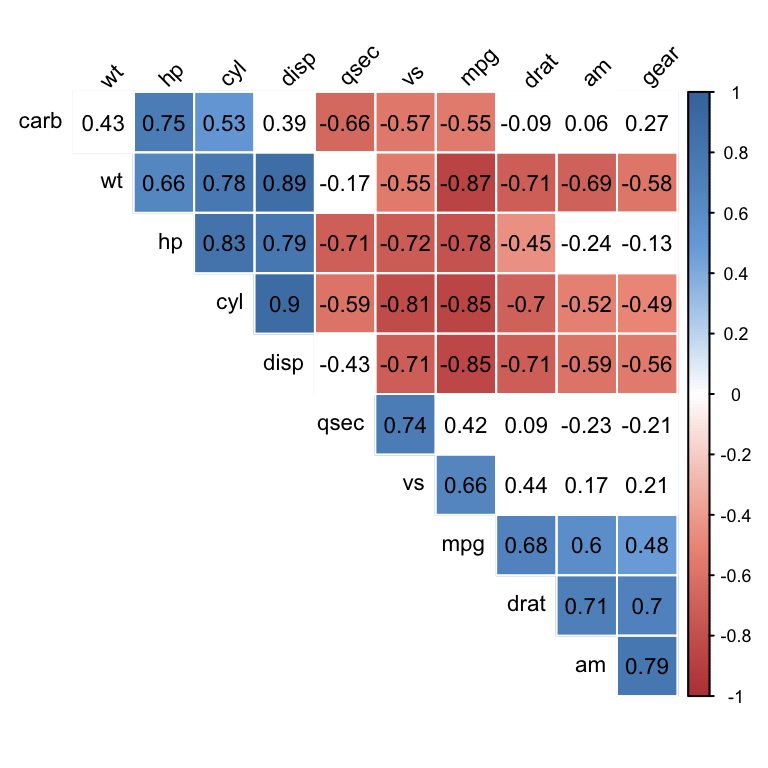

Fuente: STHDA

Para realizar una matriz de correlación o un correlograma como el anterior, recomiendo pasar por [aquí](http://www.sthda.com/english/wiki/visualize-correlation-matrix-using-correlogram).

## Introducción a tablas con kable y kableextra.

Existen varios paquetes para mostrar [tablas muy lindas](https://rfortherestofus.com/2019/11/how-to-make-beautiful-tables-in-r/), hoy veremos una forma simple usando la función `kable()` del paquete **knitr**.

Sólo usando esta función ya devuelve una tabla con un diseño más limpio y acabado

Disclaimer: este ejercicio pertenece a una serie de documentos del [Ministerio de Turismo](https://dnme-minturdep.github.io/DT6_ciencia_de_datos_turismo/tablas.html#tablas-simples-con-kable). Utiliza datos sobre [visitas a los parques nacionales](https://datos.yvera.gob.ar/dataset/parques-nacionales) según tipo de residencia del visitante.

```r
library(knitr)
library(lubridate)

#Read data
parques_ancho <- readr::read_csv("http://datos.yvera.gob.ar/dataset/458bcbe1-855c-4bc3-a1c9-cd4e84fedbbc/resource/78aea6ed-761c-4659-bdf2-7fcb0f616fad/download/serie-tiempo-parques-nacionales-mensual.csv")

#From Wide to Long
parques_largo <- parques_ancho %>%
  pivot_longer(cols = -c("indice_tiempo", "residentes", "no_residentes", "total"),
               names_to = "region_visitante",
               values_to = "valor") %>%
  mutate(region_visitante = stringr::str_replace(region_visitante, "buenos_aires*", "buenos-aires"),
         region_visitante = stringr::str_replace(region_visitante, "no_residentes", "noresidentes")) %>%
  separate(region_visitante, into = c("region", "tipo_visitante"), sep = "_") %>%
  select(-c("residentes", "no_residentes", "total"))

# Filter an summarise
parques_resumen <-  parques_largo %>%
  mutate(anio = year(indice_tiempo)) %>%
  group_by(anio, region, tipo_visitante) %>%
  summarise(valor = mean(valor)) %>%
  filter(region %in% c("cordoba", "cuyo", "patagonia", "norte"),
         anio >= 2018) %>%
  pivot_wider(names_from = "tipo_visitante", values_from = "valor")


#Make table
kable(parques_resumen, longtable = T, booktabs = T) %>%
  kable_styling(font_size = 10)
```

| anio | region | noresidentes | residentes | total |
| --- | --- | --- | --- | --- |
| 2018 | cordoba | 188.166667 | 1867.0833 | 2055.2500 |
| 2018 | cuyo | 150.166667 | 3143.5000 | 3293.6667 |
| 2018 | norte | 958.000000 | 13397.5000 | 14355.5000 |
| 2018 | patagonia | 50801.583333 | 115597.5000 | 166399.0833 |
| 2019 | cordoba | 176.083333 | 1947.4167 | 2123.5000 |
| 2019 | cuyo | 200.166667 | 3704.0833 | 3904.2500 |
| 2019 | norte | 1316.666667 | 15259.3333 | 16576.0000 |
| 2019 | patagonia | 62837.416667 | 117284.9167 | 180122.3333 |
| 2020 | cordoba | 36.916667 | 626.1667 | 663.0833 |
| 2020 | cuyo | 55.250000 | 1104.4167 | 1159.6667 |
| 2020 | norte | 428.166667 | 2615.1667 | 3043.3333 |
| 2020 | patagonia | 25615.250000 | 66082.0000 | 91697.1667 |
| 2021 | cordoba | 9.000000 | 1008.8333 | 1017.8333 |
| 2021 | cuyo | 5.583333 | 1525.1667 | 1530.7500 |
| 2021 | norte | 65.166667 | 10215.5833 | 10280.7500 |
| 2021 | patagonia | 1891.500000 | 97708.0000 | 99599.5000 |

La mayoría de las veces, el nombre de las columnas que queremos mostrar no va a ser igual que el nombre de las columnas en R. En la tabla parques_resumen, los nombres están en minúscula, sin espacios y sin “caracteres especiales” como “ñ”. Esto es útil para comunicarse con R, pero no está bueno para comunicarse con otras personas.

El argumento `col.names` permite especificar el nombre de las columnas para mostrar:

```r
kable(parques_resumen,
      longtable = T,
      booktabs = T,
      col.names = c("Año", "Región", "No Residentes", "Residentes", "Total")) %>%
  kable_styling(font_size = 10)
```

| Año | Región | No Residentes | Residentes | Total |
| --- | --- | --- | --- | --- |
| 2018 | cordoba | 188.166667 | 1867.0833 | 2055.2500 |
| 2018 | cuyo | 150.166667 | 3143.5000 | 3293.6667 |
| 2018 | norte | 958.000000 | 13397.5000 | 14355.5000 |
| 2018 | patagonia | 50801.583333 | 115597.5000 | 166399.0833 |
| 2019 | cordoba | 176.083333 | 1947.4167 | 2123.5000 |
| 2019 | cuyo | 200.166667 | 3704.0833 | 3904.2500 |
| 2019 | norte | 1316.666667 | 15259.3333 | 16576.0000 |
| 2019 | patagonia | 62837.416667 | 117284.9167 | 180122.3333 |
| 2020 | cordoba | 36.916667 | 626.1667 | 663.0833 |
| 2020 | cuyo | 55.250000 | 1104.4167 | 1159.6667 |
| 2020 | norte | 428.166667 | 2615.1667 | 3043.3333 |
| 2020 | patagonia | 25615.250000 | 66082.0000 | 91697.1667 |
| 2021 | cordoba | 9.000000 | 1008.8333 | 1017.8333 |
| 2021 | cuyo | 5.583333 | 1525.1667 | 1530.7500 |
| 2021 | norte | 65.166667 | 10215.5833 | 10280.7500 |
| 2021 | patagonia | 1891.500000 | 97708.0000 | 99599.5000 |

En Español, en general usamos la coma para separar los decimales y el punto como separador de miles.

```r
kable(parques_resumen,
      longtable = T,
      booktabs = T,
      col.names = c("Año", "Región", "No Residentes", "Residentes", "Total"),
      format.args = list(decimal.mark = ",", big.mark = ".", digits = 1, scientific = FALSE)) %>%
  kable_styling(font_size = 10)
```

| Año | Región | No Residentes | Residentes | Total |
| --- | --- | --- | --- | --- |
| 2.018 | cordoba | 188 | 1.867 | 2.055 |
| 2.018 | cuyo | 150 | 3.144 | 3.294 |
| 2.018 | norte | 958 | 13.398 | 14.356 |
| 2.018 | patagonia | 50.802 | 115.598 | 166.399 |
| 2.019 | cordoba | 176 | 1.947 | 2.124 |
| 2.019 | cuyo | 200 | 3.704 | 3.904 |
| 2.019 | norte | 1.317 | 15.259 | 16.576 |
| 2.019 | patagonia | 62.837 | 117.285 | 180.122 |
| 2.020 | cordoba | 37 | 626 | 663 |
| 2.020 | cuyo | 55 | 1.104 | 1.160 |
| 2.020 | norte | 428 | 2.615 | 3.043 |
| 2.020 | patagonia | 25.615 | 66.082 | 91.697 |
| 2.021 | cordoba | 9 | 1.009 | 1.018 |
| 2.021 | cuyo | 6 | 1.525 | 1.531 |
| 2.021 | norte | 65 | 10.216 | 10.281 |
| 2.021 | patagonia | 1.892 | 97.708 | 99.600 |

Un detalle final podría ser convertir en mayúsculas los nombres de las regiones. Para eso se puede usar la función `str_to_sentence()` del paquete **stringr**.

También podríamos cambiar año para quitar el punto. Eso lo haríamos modificando año para convertirla en tipo character.

#### kableExtra

El paquete [kableExtra](https://bookdown.org/yihui/rmarkdown-cookbook/kableextra.html), como su nombre lo indica, fue creado para extender el poder de la función kable().

#### Tablas interactivas con DT

También tenemos la posibilidad de crear tablas interactivas

```r
library(DT) #install.packages("DT")

 parques_resumen %>%
  mutate(anio = as.character(anio),
         # cambiamos región a sentence
         region = stringr::str_to_sentence(region),
         #cambiamos los decimales del redondeo
         noresidentes = round(noresidentes, 1),
         residentes = round(residentes, 1),
         total = round(total, 1)) %>%
  datatable(colnames = c("Año", "Región", "No Residentes", "Residentes", "Total"),
            class = 'cell-border stripe',
            filter = 'top',
            options = list(pageLength = 5, autoWidth = TRUE))
```

|  | Año | Región | No Residentes | Residentes | Total |
| --- | --- | --- | --- | --- | --- |
| 1 | 2018 | Cordoba | 188.2 | 1867.1 | 2055.2 |
| 2 | 2018 | Cuyo | 150.2 | 3143.5 | 3293.7 |
| 3 | 2018 | Norte | 958 | 13397.5 | 14355.5 |
| 4 | 2018 | Patagonia | 50801.6 | 115597.5 | 166399.1 |
| 5 | 2019 | Cordoba | 176.1 | 1947.4 | 2123.5 |
| 6 | 2019 | Cuyo | 200.2 | 3704.1 | 3904.2 |
| 7 | 2019 | Norte | 1316.7 | 15259.3 | 16576 |
| 8 | 2019 | Patagonia | 62837.4 | 117284.9 | 180122.3 |
| 9 | 2020 | Cordoba | 36.9 | 626.2 | 663.1 |
| 10 | 2020 | Cuyo | 55.2 | 1104.4 | 1159.7 |

[output cut: 6 more lines]

## Ejercicios

1. Abrir RStudio y crear un nuevo proyecto de R.
2. Seleccione una base de su interés, si decide importarla descargando, guárdela en la carpeta “data”dentro del proyecto.
3. Realice una breve descripción su base de datos.
4. Realice 2 visualizaciones de datos (en lo posible, tratando de interpretar alguna relación entre variables). Comente los hallazgos e impresiones.
5. Calcule y analice los coeficientes de correlación de las variables analizadas
6. Desarrolle la razón por la que usted considera que esas variables tienen un coeficiente de correlación alto.
7. Transforme su base de datos y presente al menos dos tablas.
8. Una vez finalizado el ejercicio, generar el reporte HTML con “Knit”.